# Lab 8 Questions

### Question 9

What was the p-value? Show the R-code you used to find out.

```r
require("here")
veg_dat = read.csv(here("data", "vegdata.csv"))
plant_dat = veg_dat[,-5]
pine_dat = plant_dat[, -6]

dat_tree = droplevels(subset(pine_dat, treatment %in% c("control", "clipped")))
head(dat_tree)
```

```
##    block plot date treatment pine
## 1      A   A3 1995   control    4
## 2      A   A7 1995   control    0
## 7      A   A1 1995   clipped   11
## 8      A   A2 1995   clipped    0
## 9      B   B5 1995   control    5
## 10     B   B8 1995   control    0
```

```r
pine_boot = t.test( pine ~ treatment, dat = dat_tree)
```

### Question 10

What were the endpoints of your bootstrap CI? Show the R-code you used to find out.

```r
tree_boot =
  two.boot(
    subset(dat_tree, treatment == "clipped")$pine,
    subset(dat_tree, treatment == "control")$pine,
    FUN = mean,
    R = 10000,
    na.rm = TRUE
  )

# sum(tree_boot$t >= 0)
# sum(tree_boot$t < 0)
```

### Question 11

What is the observed difference in mean tree counts and does it fall within the 95% bootstrap CI?

The observed difference in the mean tree counts is 16 so it fall within the 95% bootstrap CI.

```r
mean(tree_boot$t)
```

```
## [1] 16.15604
```

```r
quantile(tree_boot$t, c(0.025, 0.975))
```

```
##   2.5%  97.5%
##  4.500 29.875
```

### Question 12

Briefly describe the Simpson diversity index, and explain what it quantifies.

This diversity index measures diversity and the number of species present ans it quantifies the abundance.

### Question 13

Show the code you used to z-standardize the s.sidi column.

```r
dat_bird = read.csv(here("data", "bird.sub.csv"))

dat_habitat = read.csv(here("data", "hab.sub.csv"))

dat_all = merge(
  dat_bird,
  dat_habitat,
  by = c("basin", "sub"))
```

### Question 14 - 15

```r
dat_1 =
  subset(
    dat_all,
    select = c(b.sidi, s.sidi))

m = 10000
result = numeric(m)


for(i in 1:m)
{
  index_1 = sample(nrow(dat_1), replace = TRUE)
index_2 = sample(nrow(dat_1), replace = TRUE)

dat_resampled_i =
  data.frame(
    b.sidi = dat_1$b.sidi[index_1],
    s.sidi = dat_1$s.sidi[index_2]
  )

fit_resampled_i = lm(b.sidi ~ s.sidi, data = dat_resampled_i)
slope_resampled_i = coef(fit_resampled_i)[2]

#print(slope_resampled_i)
  result[i] = coef(fit_resampled_i)[2]
}


fit_1 = lm(b.sidi ~ s.sidi, data = dat_all)
coef(fit_1)
```

```
## (Intercept)      s.sidi
##  0.07116980 -0.02437131
```

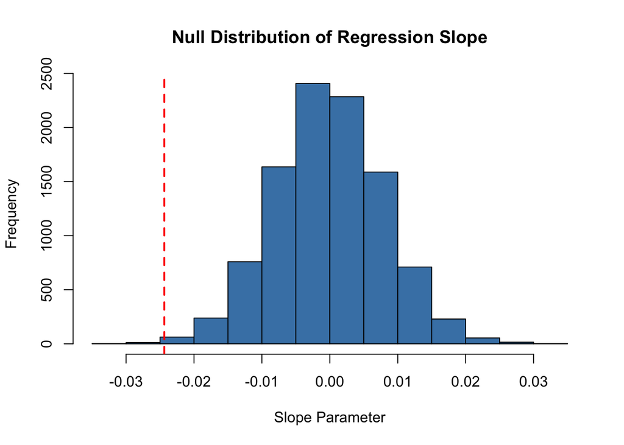

```r
slope_observed = coef(fit_1)[2]

hist(result, main = "Null Distribution of Regression Slope", xlab = "Slope Parameter", col = "steelblue")
abline(v = slope_observed, lty = 2, col = "red", lwd = 2)
```

### Question 16

What was your critical value? Was the observed slope less than the critical value?

```r
quantile(result, c(.05))
```

```
##          5%
## -0.01330198
```